### MSDS 6306 Unit 11: DDS Time Series Assignment

### Q1: Brief Financial Daa

#### Q1a: Access to the DAX index in EuStockMarkets

```r
data(EuStockMarkets) # European Stock Markets 1991-1998
head(EuStockMarkets)
```

```
##          DAX    SMI    CAC   FTSE
## [1,] 1628.75 1678.1 1772.8 2443.6
## [2,] 1613.63 1688.5 1750.5 2460.2
## [3,] 1606.51 1678.6 1718.0 2448.2
## [4,] 1621.04 1684.1 1708.1 2470.4
## [5,] 1618.16 1686.6 1723.1 2484.7
## [6,] 1610.61 1671.6 1714.3 2466.8
```

```r
DAX_Index <- EuStockMarkets[,1] # Pull specifically the DAX Index
head(DAX_Index)
```

```
## [1] 1628.75 1613.63 1606.51 1621.04 1618.16 1610.61
```

#### Q1b: Creat a rudimentary plot (blue line, informative title, label the axes accurately, add vertical line at year 1997)

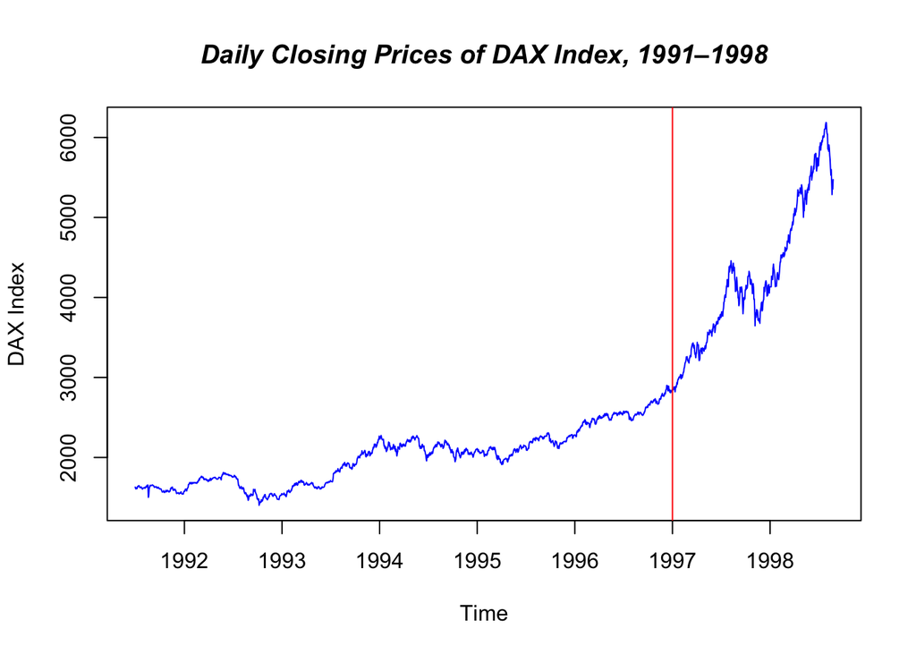

```r
DAX_stock <- ts(DAX_Index, frequency=260, start = c(1991,130))
plot(DAX_stock, col="blue", xlab="Time", ylab="DAX Index")
title(main="Daily Closing Prices of DAX Index, 1991–1998", col.main="black", font.main=4)
abline(v=1997, col="red")
```

#### Decompose the time series into its components (a multiplicative model) and creat a plot of all decomposed components (blue lines, vertical divider at year 1997)

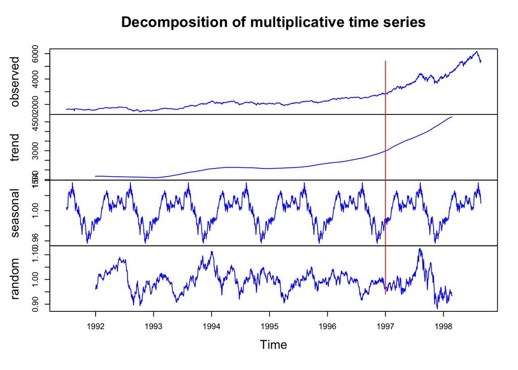

```r
DAXComp <- decompose(DAX_stock, type="mult")
plot(DAXComp, col="blue")
abline(v=1997, col="red")
```

### Q2: Temperature Data

#### Q2a: Access to maxtemp dataset from fpp2 package and check maxtemp

```r
library(fpp2)
ls("package:fpp2")
```

```
##  [1] "a10"         "arrivals"    "ausair"      "ausbeer"     "auscafe"
##  [6] "austa"       "austourists" "calls"       "debitcards"  "departures"
## [11] "elecdaily"   "elecdemand"  "elecequip"   "elecsales"   "euretail"
## [16] "gasoline"    "goog"        "goog200"     "guinearice"  "h02"
## [21] "hyndsight"   "insurance"   "livestock"   "marathon"    "maxtemp"
## [26] "melsyd"      "mens400"     "oil"         "prison"      "prisonLF"
## [31] "qauselec"    "qcement"     "qgas"        "sunspotarea" "uschange"
## [36] "usmelec"     "visnights"   "wmurders"
```

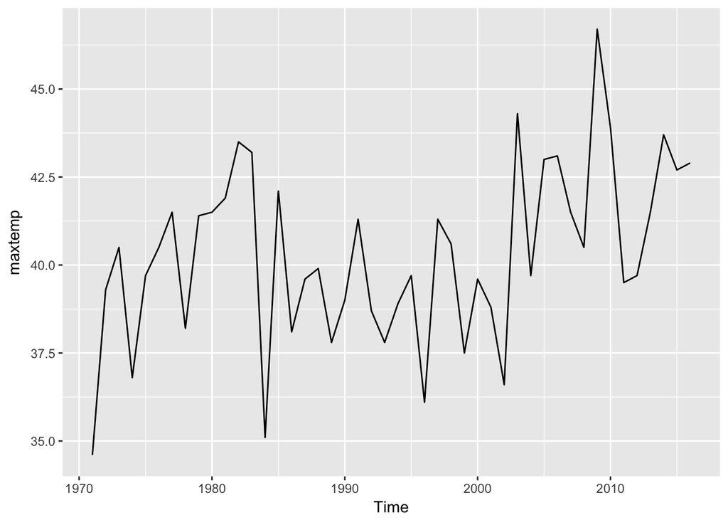

```r
autoplot(maxtemp)
```

#### Q2b: Clean data and keep inforamtion after year 1990

```r
TempSubset<-window(maxtemp, start=1990) #SES
TempTs <- ts(TempSubset, frequency=1, start=1990)
```

#### Q2c: Utilize SES to predict the next 5 years of maximum temperatures in Melbourne. Plot the actual, predicted information, and blue separate line. All on one axis to have the fit, the predicted value line overlaying it and the forcast through 2021. Find the AICC value of this fitted model.

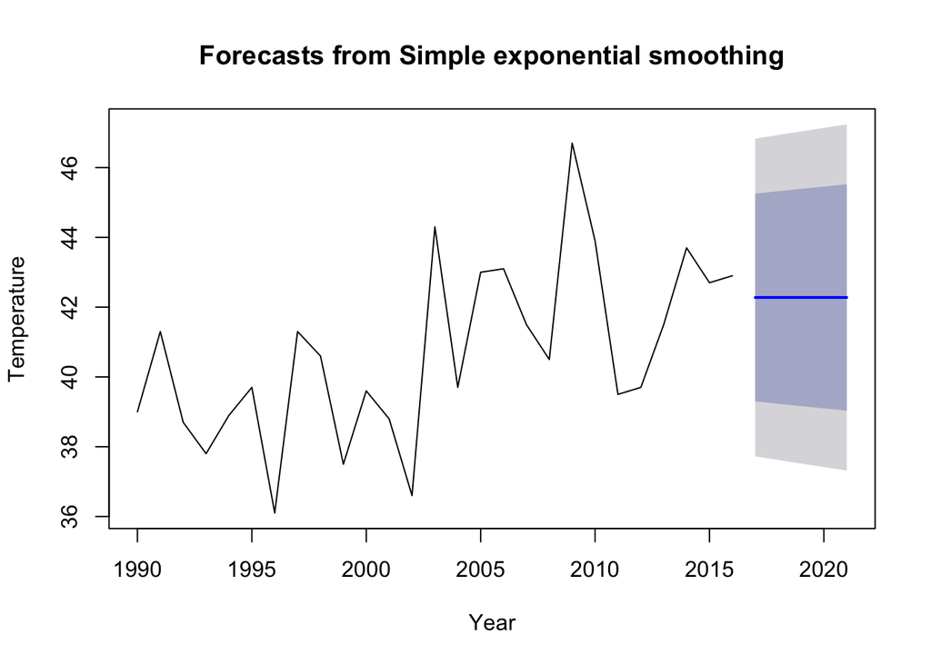

```r
TempSes <- ses(TempTs, h=5, level=c(80,95), fan=FALSE, initial=c("optimal", "simple"))
plot(TempSes, ylab="Temperature", xlab="Year") # Forecasts form SES
```

```r
tActual <-TempSes$x
tFitted <- TempSes$fitted
tForecast <-TempSes$mean

plotQ2c <-cbind(tActual, tFitted, tForecast)

library(dygraphs)
dygraph(plotQ2c, main="Utilize SES to predict maximum annual temperatures", ylab="Maximum annual temperatures (degrees Celsius)", xlab ="Years") %>%
  dySeries("tActual", label = "Actual", color="green") %>%
  dySeries("tFitted", label = "Fitted", color="red") %>%
  dySeries("tForecast", label="Forecast", color="blue") %>%
    dyHighlight(highlightCircleSize = 6, highlightSeriesOpts = list(strokeWidth = 3))
```

[interactive chart not shown]

```r
TempSes$model$aicc # AICC value 141.5302
```

```
## [1] 141.5302
```

#### Q2d: Use a damped Holt’s linear trend for 5-year prediction and plot as in Q2c (initial=“optimal”)

```r
hPredict <- holt(TempSubset, type=c("additive", "multiplicative"),initial="optimal", h=5, damped=TRUE) #with damped trend
hActual <- hPredict$x # Same as TempSubset
hFitted <- hPredict$fitted
hForecast <- hPredict$mean

hAICC <- hPredict$model$aicc #AICC value 144.5819
hAICC
```

```
## [1] 144.5819
```

```r
plotQ2d <- cbind(hActual, hFitted, hForecast)

dygraph(plotQ2d ,main = "Utilize Holt's linear trend to predict Maximum annual temperatures",ylab="Maximum annual temperatures (degrees Celsius)", xlab ="Years") %>%
    dySeries("hActual", label = "Actual", color = 'green') %>%
    dySeries("hFitted", label = "Fitted", color = 'red') %>%
    dySeries("hForecast", label = "Predicted", color = 'blue') %>%
    dyOptions(axisLineColor = "black", gridLineColor = "grey") %>%
    dyHighlight(highlightCircleSize = 6, highlightSeriesOpts = list(strokeWidth = 3))
```

[interactive chart not shown]

#### Compare the AICC of the ses() and holt() models. Which model is better here?

The AICC value for ses model (141.5302) is smaller than that from holt model (144.5819). Therefore, ses model is more accurate and better.

### Q3: The wands choose the wizard

#### Q3a: Read two files (Gregorovitch.csv and Ollivander.csv)

```r
Gregorovitch <- read.csv("/Users/shanqinggu/Desktop/Gregorovitch.csv",header = FALSE)
names(Gregorovitch) <-c("Date", "GregWand")
head(Gregorovitch)
```

```
##       Date GregWand
## 1 1/1/1970     1268
## 2 1/1/1971     1295
## 3 1/1/1972     1349
## 4 1/1/1973     1298
## 5 1/1/1974     1493
## 6 1/1/1975     1432
```

```r
Ollivander <- read.csv("/Users/shanqinggu/Desktop/Ollivander.csv",header = FALSE)
names(Ollivander) <-c("Date", "OlliWand")
head(Ollivander)
```

```
##       Date OlliWand
## 1 1/1/1970     1345
## 2 1/1/1971     1304
## 3 1/1/1972     1168
## 4 1/1/1973     1252
## 5 1/1/1974     1296
## 6 1/1/1975     1458
```

#### Q3b: Convert to proper date format

```r
Gregorovitch$Date <- as.Date(Gregorovitch$Date, format="%m/%d/%Y")
Ollivander$Date <- as.Date(Ollivander$Date, format="%m/%d/%Y")
```

#### Q3c: Use library xts to make each data frame an xts object by odering with the Date variable

```r
library(xts)
Ollivander <- xts(Ollivander$OlliWand, order.by=Ollivander$Date)
Gregorovitch <- xts(Gregorovitch$GregWand, order.by=Gregorovitch$Date)

class(c(Gregorovitch, Ollivander)) # confirm time series data
```

```
## [1] "xts" "zoo"
```

#### Q3d: Bind the two xts objects together and creat a dygraph (Effective title and x/y axes, label each series via dySeries, modify lines with different colors, activate a range selector, use dyShading to illuminate between 1995 to 1999, enable highlighting on the graph)

```r
library(dygraphs)
Wands <- cbind(Ollivander,Gregorovitch)
names(Wands) <- c('Ollivander','Gregorovitch')
dygraph(Wands, main = 'Ollivander and Gregorovitch Wands Sold Over Years', ylab = 'Wands Sold Quantity', xlab='Years') %>%
  dySeries("Ollivander", label = "Ollivander", color = 'red') %>%
  dySeries("Gregorovitch", label = "Gregorovitch", color = 'green') %>%
  dyOptions(stackedGraph = TRUE,drawPoints = TRUE, pointSize = 2) %>%
  dyLegend(show = 'always', hideOnMouseOut = FALSE, width = 200) %>%
  dyShading(from = '1995/1/1', to='1999/1/1',color = "cyan", axis = "x") %>%
  dyRangeSelector(height= 5) %>%
  dyHighlight(highlightCircleSize = 6, highlightSeriesOpts = list(strokeWidth = 3))
```

[interactive chart not shown]

#### GitHub address for HW11: https://github.com/guvp2017/SMU6306.git